# Introduction to generative modelling; Variational Autoencoders

## Encoder-Decoder Architecture

Now, we will discuss how to use neural networks in an unsupervised learning context. In fact, it was the first common application of such models.

**Dimensionality reduction** is the transformation of data from a high-dimensional space into a low-dimensional space that retains the data's most important properties. **Autoencoder** is a type of neural network that solves this task using two components: **Encoder** network $f_{\theta} : \mathcal{X} \to \mathcal{Z}$ takes $n$-dimensional input variable $x \in \mathcal{X}$ and maps it into the $m$-dimensional **latent variables** space $z \in \mathcal{Z}$. **Decoder** $g_{\psi} : \mathcal{Z} \to \mathcal{X}$ reconstruct the latent variables into the input space:

[figure not shown]

In the most cases, we assume that $n>>m$, then we call autoencoder **undercomplete**. The training process is pretty straightforward, we minimize the loss function:

$$L(x,g(f(x; \theta);\psi))$$

Loss function $L$ measures the distance between each point $x$ and its reconstruction $\tilde{x} = g(z;\psi)$.

The effectiveness of dimensionality reduction is often explained by **Manifold hypothesis**. The manifold hypothesis states that the majority of high-dimensional data sets can actually be described by a rather small number of variables, likened to the local coordinate system of the underlying manifold:

[figure not shown]

Different variants of Autoencoders can be used in many different applications:

- They are effective dimensionality reduction/compression tools.
- They are able to learn non-trivial, non-linear space transformations that are unattainable with classic algorithms.
- They can drastically reduce the dimensionality with almost non-existent information loss
- They can be used as encryption tools.
- They can denoise data.
- They can be used as generative models.

Now, we will discuss the relationship between autoencoders and generative modelling. Firstly, we could rewrite both, encoder and decoder as stochastic models, $f(x;\theta) = p_{encoder}(z|x;\theta)$ and $g(x;\psi) = p_{decoder}(x|z;\psi)$ respectively. Then, autoencoder model will be equal to:

$$p_{model}(x,z) = p_{encoder}(z|x; \theta)p_{decoder}(x|z; \psi)$$

Encoder can be easily trained by the **Maximum Likelihood Estimation** principle:

$$\hat{\theta} = \underset{\theta \in \Theta}{\text{argmax}}~p_{encoder}(z|x;\theta)$$

However, decoder's training is non-trivial; this problem cannot be solved directly, without enforcing any prior on latent variables $z$. Now, assume that a prior distribution $q$ over $z$ exists. Then we can estimate $z$ as the mode of the posterior distribution of this random variable using the **Maximum a Posteriori** estimation method:

$$ \begin{split} \hat{\psi}_{MAP} &= \underset{\psi \in \Psi}{\text{argmax}}~p_{decoder}(z|x;\psi) \\ &= \underset{\psi \in \Psi}{\text{argmax}}~p_{decoder}(x|z;\psi) ~ q(z) \\ &= \sum_{i=1}^n \log p_{decoder}(x|z;\psi) + \log q(z) \end{split} $$

This form of autoencoder is known as a **regularized autoencoder**. In a traditional framework such model is trained by adding the penalty (prior over latent variables) to the reconstruction error:

$$L(x,g(f(x; \theta); \psi)) + \Omega(z)$$

## Variational Autoencoder

[Variational Autoencoders](https://arxiv.org/pdf/1312.6114.pdf) are the class of autoencoders that works using a very simple principle; instead of embedding a variable $x$ as a latent vector $z$ they embed it in the form of a probability distribution (e.g. gaussian) parameters. Then encoder draws a sample from this distribution and reconstructs the new observation:

[figure not shown]

What are the principles behind such a network?

Our goal is to approximate the probability distribution $p(x,z)$, that describes a data generating process:

$$p(x,z) = p(x|z)p(z)$$

With such a model, we could easily generate new observations using two step procedure:

1. Draw a latent vector $z_i \sim p(z)$
2. Reconstruct the observation $\hat{x}_i \sim p(x|z)$

To find a solution, we must learn the relation between variables $x$ and latents $z$:

$$p(z|x) = \frac{p(x|z)p(z)}{p(x)}$$

It is impossible to find this probability analytically, namely solving an integral $p(x) = \int_\mathcal{Z} {p(x|z)p(z)}dz$ requires full knowledge about the space $\mathcal{Z}$. Instead, we can approximate $p(z|x)$ using a prior distribution $q_{\phi}(z|x)$ from a family of distributions $\phi$. With such assumption, our goal reduces to solving the following expectation: $$E_{z \sim q_{\phi}}[p(x | z)]$$

But how to measure the similarity of $q_{\phi}$ and $p$?

With **Kullback-Leibler divergence**:

$$d_{KL}(q_{\phi}(z|x)||p(z|x)) = E_{q_{\phi}}[\log q_{\phi}(z|x)] - E_{q_{\phi}}[\log p(x,z)] + \log p(x)$$

Then, our goal is to find such a distribution $q_{\phi}^*$ than minimizes:

$$q_{\phi}^* = \underset{\phi}{\operatorname{argmin}}~d_{KL}(q_{\phi}(z|x)||p(z|x))$$

But computing Kullback-Leibler divergence still requires the value of $p(x)$. How could we omit it?

Let us define the **Evidence Lower BOund** (ELBO):

$$ELBO(\phi) = E_{q_{\phi}}[\log p(x,z)] - E_{q_{\phi}}[\log q_{\phi}(z|x)]$$

Notice that:

$$\log p(x) = ELBO(\phi) + d_{KL}(q_{\phi}(z|x)||p(z|x))$$

By Jensen inequality, Kullback-Leibler divergence is always nonnegative, thus the goal of minimization of Kullback-Leibler divergence is equivalent to maximizing ELBO. Moreover, latent variables in variational autoencoder are local, namely, they are used to generate single observations. As a result, we can compute ELBO pointwise and then average the results:

$$ELBO(\theta,\psi)=\sum_{i=1}^n E_{q_{\phi}(z|x_i;\theta)}[\log p(x_i|z; \psi)] - \sum_{i=1}^n d_{KL}(q(z|x_i; \theta)||p(z))$$

Thus, a loss function of variational autoencoder is equal to:

$$L(\theta,\psi) = -\sum_{i=1}^n E_{q_{\phi}(z|x_i;\theta)}[\log p(x_i|z; \psi)] + \sum_{i=1}^n d_{KL}(q(z|x_i; \theta)||p(z))$$

From a practical standpoint, a variational autoencoder is just a form of regularized autoencoder. The first element of the loss function $\sum_{i=1}^n E_{q_{\phi}(z|x_i;\theta)}[\log p(x_i|z; \psi)]$ is a reconstruction error, that allows the model to learn a proper mapping of variables $x_i$ into latents $z_i$ and then, reconstruct them with the lowest possible quality loss. However, if we decide to train a model only with the reconstruction error, we will end up with points separated in the latent space and a fully deterministic model.

Thus, we add a regularization factor, in a form of a Kullback-Leibler divergence, that forces the model to fully cover the latent space:

[figure not shown]

As a result, variational autoencoders are able to not only reduce the dimensionality of the data, but also [learn the underlying manifold](https://www.deeplearningbook.org/contents/generative_models.html):

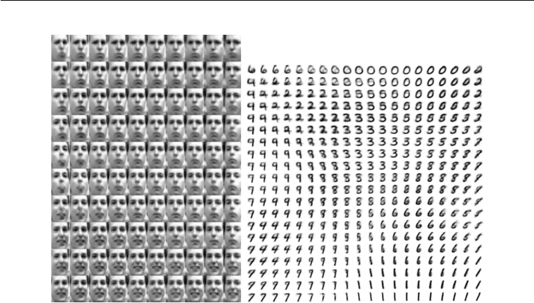